[figure not shown]

# Git workflows for verifying AI outputs

Day 4 · Intro to Agentic AI at the WBG

Kristoffer Bjärkefur

Impact Analytics

8 October 2026

## Agenda

- Which workflow is this for?
- Unleash the creativity of AI, but stay in control with Git
- Use GitHub’s built-in review tools
- Give the agent its own parallel space (advanced)

# Which Workflow Is This For?

## Recap from human-in-the-loop

This session is about how Git and GitHub can help you verify what we refer to as Static Tools below.

### Static Tools

- Examples: reports, presentation decks, code, etc.
- Created by team members, vendors, or AI tools
- The product owner reviews the finalized output before the product is used or published. This is old-fashioned “human-in-the-loop” review.

### Decision-Making Products

- Examples: review bots and interactive bots such as chatbots
- Set up by team members, vendors, or AI tools
- Output is generated in real time. We can do a final review of the setup, but not of the output, unless we have a “human-in-the-loop” checkpoint.

# Unleash the Creativity of AI, but Stay in Control with Git

## Let the agent finish, then review with Git

When an AI agent modifies files in a repository tracked by Git:

1. **Let the agent work** until the task is complete – no need to use tools in Git to review every edit before the task is done.
2. **Review the final result with Git** – use GitHub Desktop to review the edits before pushing them to your project repository.
   - Other Git clients work too, but a GUI client (i.e., not Git on the command line) makes this much easier.
3. **Commit only what you approve** – stage and commit the edits you have reviewed.
4. **Not happy?** – ask the agent to fix it, or discard the changes.

## Git shows you every AI edit – no matter how small

- Git gives you a complete, line-by-line record of what the agent did – you review the outcome, not the process.
- Ask the agent to explain any edit you do not understand or do not see the need for before committing it.

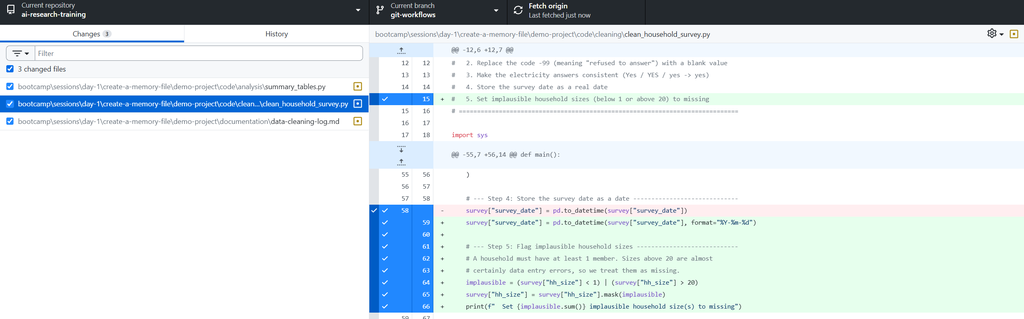

## Commit piece by piece in understandable chunks

- GUI Git clients let you select what to include in each commit. A commit does not have to include – *and probably should not include* – all changes at once.
- Committing in understandable chunks lets you document and preserve the understanding you gain during the review.
- If another user did not commit in understandable chunks, use AI to summarize edits.

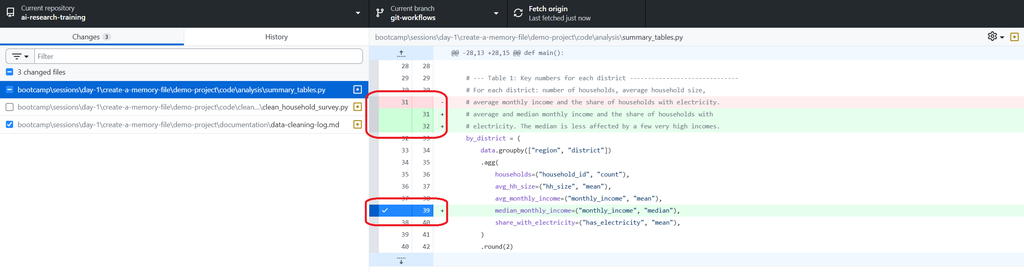

## Discard what you do not need

- Agents are verbose. Do not commit unnecessary verbosity to your repository, as it makes the repository hard for humans to follow.
- Update the memory file with instructions that prevent the agent from repeating the same verbosity.

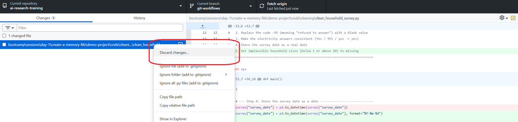

# Use GitHub’s Built-in Review Tools

## Quick recap

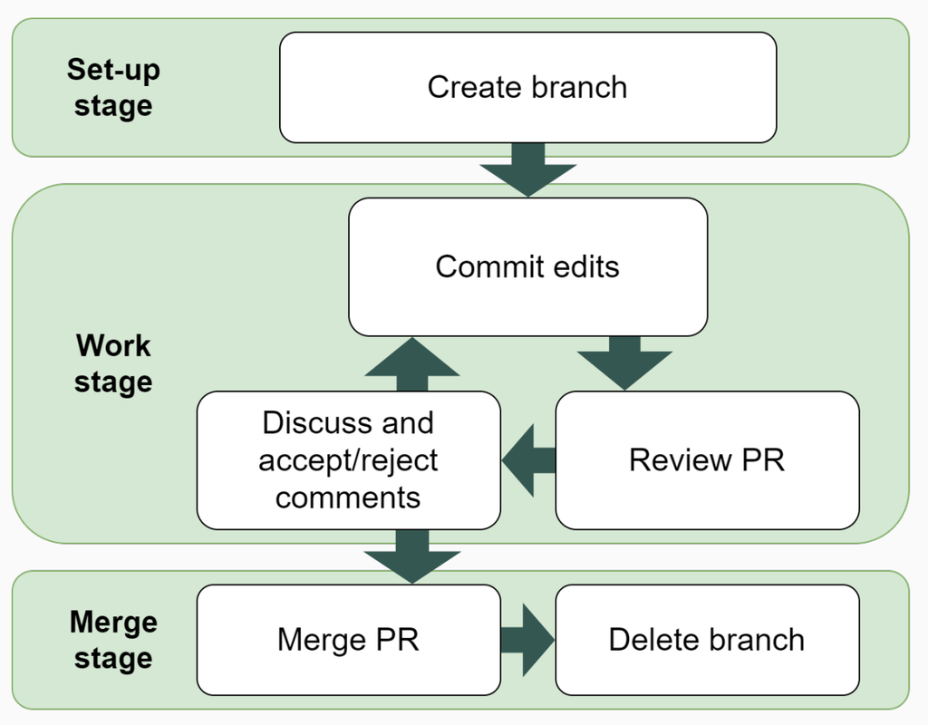

## Review your changes in a pull request

- For each task you want to hand over to the agent, create a branch for that task and check out that branch in your clone.
- Ask the agent to perform the task, using the steps described in the previous section.
- Push the agent’s branch to GitHub and open a **Pull Request (PR)** into `main`.
- The PR shows the complete diff of all changes in one place.
- Comment on specific lines or ask colleagues to review. Resolve all conversations before merging.
- The PR keeps a permanent record of what was changed, why (all the conversations), and who approved it.

For a full introduction to PRs and more detail on the review features, see the slides from the Impact Analytics PR training: https://osf.io/e54gy/files/umqzn

## GitHub Copilot as a PR reviewer

If you also have a GitHub Copilot license:

- Request **Copilot** as a reviewer on your PR.
- Copilot leaves review comments, often with suggested changes you can apply directly.
- A second AI reviewing the first AI’s work *can* catch issues the authoring agent missed.
- One agent reviewing another is no guarantee, but the task is different: Copilot does not follow your initial prompt; it only reviews whether the final set of commits makes sense.

Copilot **assists** the review – it does not replace it. You are still the product owner and are responsible for what gets merged.

[figure not shown]

## GitHub Copilot as a PR reviewer - Example

[figure not shown]

[figure not shown]

Examples from https://github.com/dime-worldbank/ai-research-training/pull/13

# Give the Agent Its Own Parallel Space – Advanced

## Worktrees: parallel tasks without collisions

- So far in this presentation, we have created a separate branch for each agent task.
- But our clone still needs to have that branch checked out while the agent works on it.
- This prevents us from going back to the branch where we want to do our own work until the agent’s task is finished and its branch is merged.
- It also prevents us from having agents work on different tasks in different branches simultaneously.
- Is there a solution to this problem?
- Yes, and it is called worktrees. A **worktree** is an extra working directory with its own branch in the same repository – once the task is completed, it can be reviewed in a PR.
- This more advanced workflow exists in both agents we have used, but WBG GitHub Copilot lacks one permission it needs to use worktrees.

## Worktrees: what they are

**Warning**

Disclaimer: Claude is new at the WBG and we have not yet been able to test this thoroughly.

- Each worktree is like a separate branch saved in its own folder – for Claude, it is `.claude/worktrees/<worktree-name>`.
- An agent session in one worktree only sees that worktree’s files, i.e., what is visible on that branch. Edits made in a worktree only appear in that worktree’s branch.
- Run several sessions in parallel – a feature, a bugfix, new tests – without them overwriting each other’s edits.
- All worktrees share the same Git history, but untracked files are **not** there initially. A common example is packages installed in virtual environments (`renv`, `venv`), which you may need to reinstall.

## Worktrees: Diagram with example

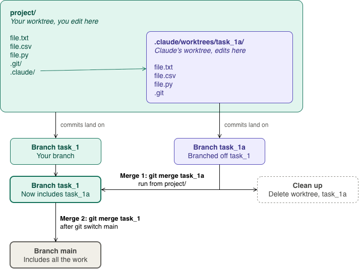

## Worktrees: how to use them

**Warning**

Before doing anything, make sure that `.claude/worktrees/` or `**/worktrees/` is added to your `.gitignore`. Otherwise this folder will be committed as part of the branch checked out in your clone.

**With Claude Code on the command line:** start a session with `claude --worktree`. The Claude Desktop app can create a worktree for each new session automatically.

**With Git on the command line:** replace `<branchname>` with the name of the branch you want to create for the worktree. This only works for branch names that do not already exist.

```bash
git worktree add .claude/worktrees/<branchname> -b <branchname>
```

Open that folder in a new VS Code workspace (*File → Open Folder*) and start the agent there.

Docs: https://code.claude.com/docs/en/worktrees.md

## Worktrees: pushing and opening a PR

A worktree branch is a regular branch in the same repository – **no special steps are needed**. Push it and open a PR exactly as you would for any other branch.

- Commit the agent’s work **inside the worktree folder** – uncommitted changes stay in that folder only.
  - If you want the agent to commit its edits, instruct it to do so in the memory file or in the prompt for this task.
- A branch can only be checked out in one place at a time, so you cannot switch to it in your main clone (e.g., in GitHub Desktop) while the worktree exists. Test and commit the new edits from within the worktree folder.
  - Ask the agent to do this for you if you get stuck.
- Once the PR is merged, remember to remove the worktree with `git worktree remove`.

# Thank You! – Questions?